# Load the data

```python
import pandas
import numpy
import sys
%matplotlib inline
import matplotlib.pyplot as plt
from pandas.tools.plotting import scatter_matrix
import seaborn as sns
import numpy as np
import time
from sklearn import metrics
from sklearn import cross_validation
from sklearn.metrics import classification_report
from sklearn.metrics import confusion_matrix, roc_curve, auc
from sklearn.metrics import accuracy_score
from sklearn.tree import DecisionTreeClassifier
from sklearn.neighbors import KNeighborsClassifier
from sklearn.discriminant_analysis import LinearDiscriminantAnalysis
from sklearn.naive_bayes import GaussianNB
from sklearn.svm import SVC
from IPython.display import set_matplotlib_formats
set_matplotlib_formats('png', 'pdf')
# fix random seed for reproducibility
plt.rcParams['figure.figsize'] = (15, 6)
```

```python
# fix random seed for reproducibility
seed = 7
numpy.random.seed(seed)
plt.rcParams['figure.figsize'] = (15, 6)
url = "https://archive.ics.uci.edu/ml/machine-learning-databases/car/car.data"
names = ['buying', 'maint', 'doors', 'persons', 'lug_boot', 'safety', 'class']
data = pandas.read_csv('car.data.txt', names=names)
peek = data.head(10)
print(peek)
```

```
  buying  maint doors persons lug_boot safety  class
0  vhigh  vhigh     2       2    small    low  unacc
1  vhigh  vhigh     2       2    small    med  unacc
2  vhigh  vhigh     2       2    small   high  unacc
3  vhigh  vhigh     2       2      med    low  unacc
4  vhigh  vhigh     2       2      med    med  unacc
5  vhigh  vhigh     2       2      med   high  unacc
6  vhigh  vhigh     2       2      big    low  unacc
7  vhigh  vhigh     2       2      big    med  unacc
8  vhigh  vhigh     2       2      big   high  unacc
9  vhigh  vhigh     2       4    small    low  unacc
```

```python
shape = data.shape
print(shape)
```

```
(1728, 7)
```

```python
types = data.dtypes
print(types)
```

```
buying      object
maint       object
doors       object
persons     object
lug_boot    object
safety      object
class       object
dtype: object
```

```python
pandas.set_option('display.width', 100)
pandas.set_option('precision', 3)
description = data.describe()
print(description)
```

```
       buying maint doors persons lug_boot safety  class
count    1728  1728  1728    1728     1728   1728   1728
unique      4     4     4       3        3      3      4
top       med   med     4    more      med    med  unacc
freq      432   432   432     576      576    576   1210
```

```python
class_counts = data.groupby('class').size()
print(class_counts)
```

```
class
acc       384
good       69
unacc    1210
vgood      65
dtype: int64
```

```python
correlations = data.corr(method='pearson')
print(correlations)
```

```
Empty DataFrame
Columns: []
Index: []
```

encode the labels vhigh = 4 high=3 med=2 low=1 5more = 6 more =5 small =1 med=2 big=3 unacc=1 acc=2 good=3 vgood=4

```python
data = data.replace('vhigh',4)
data = data.replace('high',3)
data = data.replace('med',2)
data = data.replace('low',1)
###################
data = data.replace('5more',6)
data = data.replace('more',5)
#######################
data = data.replace('med',2)
data = data.replace('small',1)
data = data.replace('big',3)
###################
data = data.replace('unacc',1)
data = data.replace('acc',2)
data = data.replace('good',3)
data = data.replace('vgood',4)
```

```python
skew = data.skew()
print(skew)
```

```
buying      0.000
maint       0.000
doors       0.435
persons    -0.382
lug_boot    0.000
safety      0.000
class       1.980
dtype: float64
```

```python
peek = data.head(10)
print(peek)
```

```
   buying  maint doors persons  lug_boot  safety  class
0       4      4     2       2         1       1      1
1       4      4     2       2         1       2      1
2       4      4     2       2         1       3      1
3       4      4     2       2         2       1      1
4       4      4     2       2         2       2      1
5       4      4     2       2         2       3      1
6       4      4     2       2         3       1      1
7       4      4     2       2         3       2      1
8       4      4     2       2         3       3      1
9       4      4     2       4         1       1      1
```

```python
types = data.dtypes
print(types)
```

```
buying       int64
maint        int64
doors       object
persons     object
lug_boot     int64
safety       int64
class        int64
dtype: object
```

```python
data["doors"] = data["doors"].astype("int64")
data["persons"] = data["persons"].astype("int64")
types = data.dtypes
print(types)
```

```
buying      int64
maint       int64
doors       int64
persons     int64
lug_boot    int64
safety      int64
class       int64
dtype: object
```

```python
correlations = data.corr(method='pearson')
print(correlations)
```

```
          buying  maint      doors    persons   lug_boot  safety  class
buying     1.000  0.000  0.000e+00  0.000e+00  0.000e+00   0.000 -0.283
maint      0.000  1.000  0.000e+00  0.000e+00  0.000e+00   0.000 -0.232
doors      0.000  0.000  1.000e+00  1.073e-16  0.000e+00   0.000  0.060
persons    0.000  0.000  1.073e-16  1.000e+00  2.524e-19   0.000  0.373
lug_boot   0.000  0.000  0.000e+00  2.524e-19  1.000e+00   0.000  0.158
safety     0.000  0.000  0.000e+00  0.000e+00  0.000e+00   1.000  0.439
class     -0.283 -0.232  5.984e-02  3.735e-01  1.579e-01   0.439  1.000
```

# Visulize the data

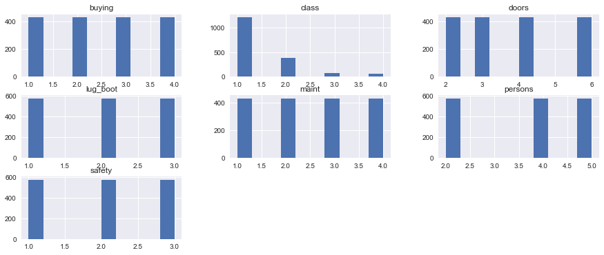

```python
data.hist()
plt.show()
```

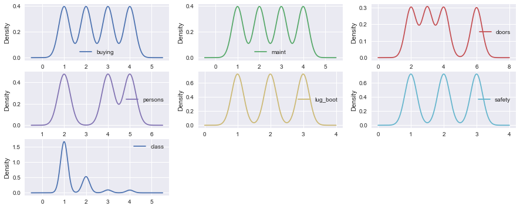

```python
data.plot(kind='density', subplots=True, layout=(3,3), sharex=False)
plt.show()
```

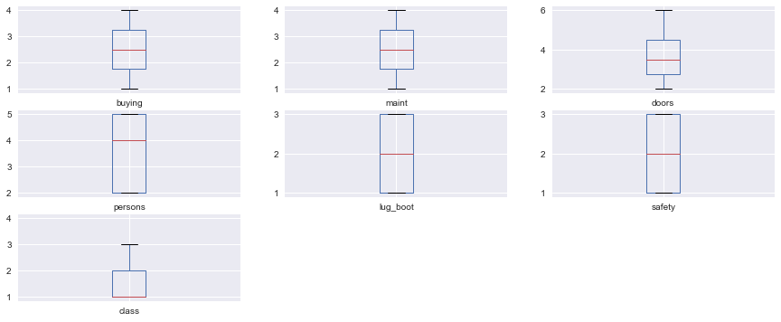

```python
data.plot(kind='box', subplots=True, layout=(3,3), sharex=False, sharey=False)
plt.show()
```

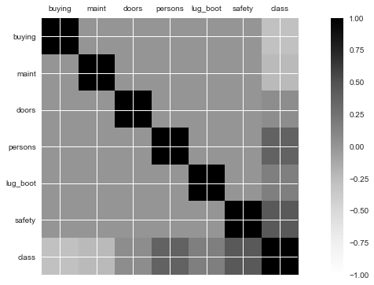

```python
correlations = data.corr()
# plot correlation matrix
fig = plt.figure()
ax = fig.add_subplot(111)
cax = ax.matshow(correlations, vmin=-1, vmax=1)
fig.colorbar(cax)
ticks = numpy.arange(0,7,1)
ax.set_xticks(ticks)
ax.set_yticks(ticks)
ax.set_xticklabels(names)
ax.set_yticklabels(names)
plt.show()
```

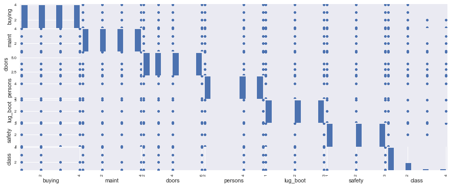

```python
scatter_matrix(data)
plt.show()
```

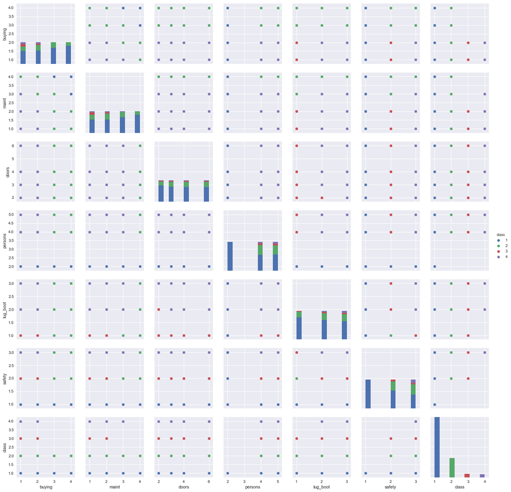

```python
import seaborn as sns
sns.pairplot(data, hue='class')
```

# Prepare the data for classification

```python
from sklearn import preprocessing
dataset = data.values
X = dataset[:,0:6].astype(float)
Y = dataset[:,6]
features = preprocessing.scale(X)
target = Y
```

```python
from sklearn.cross_validation import train_test_split
# Extracting 20% testing data
X_train_feature, X_deploy, y_train_feature, y_deploy = train_test_split(
    features, target, test_size=0.20, random_state=17)
# Make training and validation data sets for building the models and choose the hyperparameters
X_train, X_test, y_train, y_test = train_test_split(
    X_train_feature, y_train_feature, test_size=0.20, random_state=17)
print('Number of training examples',len(X_train))
print('Number of validation examples',len(X_test))
print('Number of testing examples',len(X_deploy))
```

```
Number of training examples 1105
Number of validation examples 277
Number of testing examples 346
```

## Preproccing

```python
from sklearn import preprocessing
# normalize the data attributes
X_train = preprocessing.normalize(X_train)
X_test = preprocessing.normalize(X_test)
X_deploy = preprocessing.normalize(X_deploy)
# standardize the data attributes
X_train = preprocessing.scale(X_train)
X_test = preprocessing.scale(X_test)
X_deploy = preprocessing.scale(X_deploy)
```

# Feature Selection

```python
from sklearn import metrics
from sklearn.ensemble import ExtraTreesClassifier
model = ExtraTreesClassifier()
model.fit(X_train, y_train)
# display the relative importance of each attribute
print(model.feature_importances_)
```

```
[ 0.16189262  0.18480158  0.05791956  0.22679451  0.0919009   0.27669083]
```

```python
data.tail()
```

[output not shown]

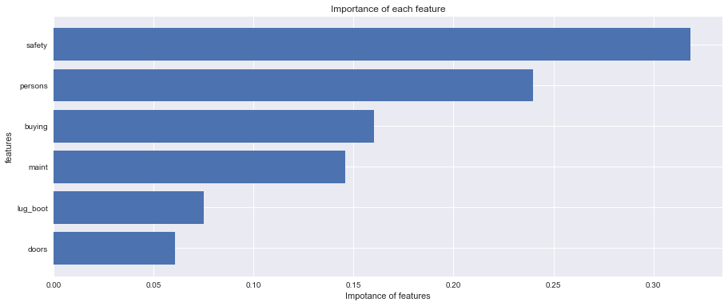

```python
# importabt of features according to random forest
from sklearn.ensemble import RandomForestClassifier
rf = RandomForestClassifier(n_estimators = 15)
rf.fit(X, Y)
imp = rf.feature_importances_
names = data.columns

imp, names = zip(*sorted(zip(imp,names)))
plt.barh(range(len(names)), imp, align = 'center')
plt.yticks(range(len(names)), names)

plt.xlabel('Impotance of features')
plt.ylabel('features')
plt.title('Importance of each feature')
plt.show()
```

# Building classifiers

## KNN classifier

It turns out that k=5 is the best choose of k on the validation set

```python
from sklearn.neighbors import KNeighborsClassifier
clf_neigh = KNeighborsClassifier(n_neighbors=5)
#Training
start_time = time.time()
clf_neigh.fit(X_train, y_train)
print("The time for training KNN is  %s seconds " % (time.time() - start_time))

# Make a prediction
y_pred = clf_neigh.predict(X_test)
print("\n===================================================================")
print("The accuracy on validation dataset of Knn : \t", metrics.accuracy_score(y_test, y_pred))
print("===================================================================")
print(metrics.classification_report(y_test, y_pred, target_names=['unacc', 'acc', 'good','vgood']))
```

```
The time for training KNN is  0.0017209053039550781 seconds

===================================================================
The accuracy on validation dataset of Knn : 	 0.927797833935
===================================================================
             precision    recall  f1-score   support

      unacc       0.94      0.99      0.96       191
        acc       0.89      0.80      0.84        60
       good       0.80      0.50      0.62         8
      vgood       1.00      0.89      0.94        18

avg / total       0.93      0.93      0.92       277
```

## SVM classifier

### Linear SVM "LinearSVC"

It turns out that C=20 is the best on the validation set

```python
from sklearn.svm import LinearSVC
clf_svm_linear = LinearSVC(C=20.0)
#Training
start_time = time.time()
clf_svm_linear.fit(X_train, y_train)
print("The time for training SVM is  %s seconds " % (time.time() - start_time))

# Make a prediction
y_pred = clf_svm_linear.predict(X_test)
print("\n===================================================================")
print("The accuracy on validation dataset of Linear SVC: \t", metrics.accuracy_score(y_test, y_pred))
print("===================================================================")
print(metrics.classification_report(y_test, y_pred, target_names=['unacc', 'acc', 'good','vgood']))
```

```
The time for training SVM is  0.057530879974365234 seconds

===================================================================
The accuracy on validation dataset of Linear SVC: 	 0.819494584838
===================================================================
             precision    recall  f1-score   support

      unacc       0.87      0.96      0.91       191
        acc       0.60      0.50      0.55        60
       good       0.33      0.12      0.18         8
      vgood       1.00      0.67      0.80        18

avg / total       0.80      0.82      0.81       277
```

### SVM "SVC" with kernel='rbf'

It turns out that C=5 is the best on the validation set

```python
from sklearn.svm import SVC
clf_svm = SVC(C=5.0, kernel='rbf')
#Training
start_time = time.time()
clf_svm.fit(X_train, y_train)
print("The time for training SVM is  %s seconds " % (time.time() - start_time))

# Make a prediction
y_pred = clf_svm.predict(X_test)
print("\n===================================================================")
print("The accuracy on validation dataset of SVC: \t", metrics.accuracy_score(y_test, y_pred))
print("===================================================================")
print(metrics.classification_report(y_test, y_pred, target_names=['unacc', 'acc', 'good','vgood']))
```

```
The time for training SVM is  0.01436305046081543 seconds

===================================================================
The accuracy on validation dataset of SVC: 	 0.949458483755
===================================================================
             precision    recall  f1-score   support

      unacc       0.95      0.99      0.97       191
        acc       0.93      0.83      0.88        60
       good       0.88      0.88      0.88         8
      vgood       1.00      0.94      0.97        18

avg / total       0.95      0.95      0.95       277
```

## Decsion Tree classifier

### DT with Gini impurity "gini", CART (Classification and Regression Trees)

It turns out that min_samples_split=2 is the best on the validation set

```python
# CART tree
from sklearn.tree import DecisionTreeClassifier
clf_dt = DecisionTreeClassifier(min_samples_split=2)
#Training
start_time = time.time()
clf_dt.fit(X_train, y_train)
print("The time for training Decision Tree is  %s seconds " % (time.time() - start_time))

# Make a prediction
y_pred = clf_dt.predict(X_test)
print("\n===================================================================")
print("The accuracy on validation dataset of Linear SVC: \t", metrics.accuracy_score(y_test, y_pred))
print("===================================================================")
print(metrics.classification_report(y_test, y_pred, target_names=['unacc', 'acc', 'good','vgood']))
```

```
The time for training Decision Tree is  0.002170085906982422 seconds

===================================================================
The accuracy on validation dataset of Linear SVC: 	 0.935018050542
===================================================================
             precision    recall  f1-score   support

      unacc       0.97      0.96      0.96       191
        acc       0.87      0.88      0.88        60
       good       0.67      1.00      0.80         8
      vgood       1.00      0.83      0.91        18

avg / total       0.94      0.94      0.94       277
```

### DT with “entropy” for the information gain, C4.5 (aka J48 is an open source Java Weka) and C5.0

It turns out that min_samples_split=2 is the best on the validation set

```python
# Here I use C5.0 tree as its more accurate that C4.5 and more recent.
from sklearn.tree import DecisionTreeClassifier
clf_dt_IG = DecisionTreeClassifier(criterion='entropy', min_samples_split=2)
#Training
start_time = time.time()
clf_dt_IG.fit(X_train, y_train)
print("The time for training Decision Tree is  %s seconds " % (time.time() - start_time))

# Make a prediction
y_pred = clf_dt_IG.predict(X_test)
print("\n===================================================================")
print("The accuracy on validation dataset of Linear SVC: \t", metrics.accuracy_score(y_test, y_pred))
print("===================================================================")
print(metrics.classification_report(y_test, y_pred, target_names=['unacc', 'acc', 'good','vgood']))
```

```
The time for training Decision Tree is  0.002916097640991211 seconds

===================================================================
The accuracy on validation dataset of Linear SVC: 	 0.945848375451
===================================================================
             precision    recall  f1-score   support

      unacc       0.98      0.97      0.97       191
        acc       0.88      0.88      0.88        60
       good       0.64      0.88      0.74         8
      vgood       1.00      0.94      0.97        18

avg / total       0.95      0.95      0.95       277
```

Ensemble methods

## Bagging Method

### Bagging Method with Knn

Using Best KNN classifier fitted the data, each built on random subsets of 50% of the samples and 50% of the features.

```python
from sklearn.ensemble import BaggingClassifier
from sklearn.neighbors import KNeighborsClassifier
clf_dt_BGKN = BaggingClassifier(KNeighborsClassifier(n_neighbors=5),
                             max_samples=0.5, max_features=0.5)
start_time = time.time()
clf_dt_BGKN.fit(X_train, y_train)
print("The time for training Bagging Knn is  %s seconds " % (time.time() - start_time))

# Make a prediction
y_pred = clf_dt_BGKN.predict(X_test)
print("\n===================================================================")
print("The accuracy on validation dataset of Linear SVC: \t", metrics.accuracy_score(y_test, y_pred))
print("===================================================================")
print(metrics.classification_report(y_test, y_pred, target_names=['unacc', 'acc', 'good','vgood']))
```

```
The time for training Bagging Knn is  0.011404037475585938 seconds

===================================================================
The accuracy on validation dataset of Linear SVC: 	 0.725631768953
===================================================================
             precision    recall  f1-score   support

      unacc       0.72      1.00      0.84       191
        acc       0.83      0.17      0.28        60
       good       0.00      0.00      0.00         8
      vgood       0.00      0.00      0.00        18

avg / total       0.68      0.73      0.64       277
```

### Bagging Method with DT

Using Best DT with 'entropy', each built on random subsets of 50% of the samples and 50% of the features.

```python
from sklearn.ensemble import BaggingClassifier
from sklearn.tree import DecisionTreeClassifier
clf_dt_BGDT = BaggingClassifier(DecisionTreeClassifier(criterion='entropy', min_samples_split=2),
                             max_samples=0.5, max_features=0.5)
start_time = time.time()
clf_dt_BGDT.fit(X_train, y_train)
print("The time for training Bagging DT is  %s seconds " % (time.time() - start_time))

# Make a prediction
y_pred = clf_dt_BGDT.predict(X_test)
print("\n===================================================================")
print("The accuracy on validation dataset of Linear SVC: \t", metrics.accuracy_score(y_test, y_pred))
print("===================================================================")
print(metrics.classification_report(y_test, y_pred, target_names=['unacc', 'acc', 'good','vgood']))
```

```
The time for training Bagging DT is  0.021948814392089844 seconds

===================================================================
The accuracy on validation dataset of Linear SVC: 	 0.772563176895
===================================================================
             precision    recall  f1-score   support

      unacc       0.77      0.98      0.86       191
        acc       0.77      0.40      0.53        60
       good       0.00      0.00      0.00         8
      vgood       1.00      0.17      0.29        18

avg / total       0.76      0.77      0.73       277
```

## Random Forest

DT with 'gini'

```python
from sklearn.ensemble import RandomForestClassifier
clf_dt_RF = RandomForestClassifier()
#Training
start_time = time.time()
clf_dt_RF.fit(X_train, y_train)
print("The time for training Decision Tree is  %s seconds " % (time.time() - start_time))

# Make a prediction
y_pred = clf_dt_RF.predict(X_test)
print("\n===================================================================")
print("The accuracy on validation dataset of Linear SVC: \t", metrics.accuracy_score(y_test, y_pred))
print("===================================================================")
print(metrics.classification_report(y_test, y_pred, target_names=['unacc', 'acc', 'good','vgood']))
```

```
The time for training Decision Tree is  0.017611980438232422 seconds

===================================================================
The accuracy on validation dataset of Linear SVC: 	 0.913357400722
===================================================================
             precision    recall  f1-score   support

      unacc       0.96      0.97      0.97       191
        acc       0.83      0.83      0.83        60
       good       0.40      0.50      0.44         8
      vgood       0.93      0.72      0.81        18

avg / total       0.92      0.91      0.91       277
```

### Ada Boost

DT with 'gini'

```python
from sklearn.ensemble import AdaBoostClassifier
clf_dt_AD = AdaBoostClassifier()
#Training
start_time = time.time()
clf_dt_AD.fit(X_train, y_train)
print("The time for training Decision Tree is  %s seconds " % (time.time() - start_time))

# Make a prediction
y_pred = clf_dt_AD.predict(X_test)
print("\n===================================================================")
print("The accuracy on validation dataset of Linear SVC: \t", metrics.accuracy_score(y_test, y_pred))
print("===================================================================")
print(metrics.classification_report(y_test, y_pred, target_names=['unacc', 'acc', 'good','vgood']))
```

```
The time for training Decision Tree is  0.08572697639465332 seconds

===================================================================
The accuracy on validation dataset of Linear SVC: 	 0.888086642599
===================================================================
             precision    recall  f1-score   support

      unacc       0.95      0.92      0.94       191
        acc       0.75      0.77      0.76        60
       good       0.53      1.00      0.70         8
      vgood       1.00      0.89      0.94        18

avg / total       0.90      0.89      0.89       277
```

## Naive Bayes methods

```python
from sklearn.naive_bayes import GaussianNB
clf_NB = GaussianNB()
#Training
start_time = time.time()
clf_NB.fit(X_train, y_train)
print("The time for training Naive Bayes is  %s seconds " % (time.time() - start_time))

# Make a prediction
y_pred = clf_NB.predict(X_test)
print("\n===================================================================")
print("The accuracy on validation dataset of Linear SVC: \t", metrics.accuracy_score(y_test, y_pred))
print("===================================================================")
print(metrics.classification_report(y_test, y_pred, target_names=['unacc', 'acc', 'good','vgood']))
```

```
The time for training Naive Bayes is  0.0014820098876953125 seconds

===================================================================
The accuracy on validation dataset of Linear SVC: 	 0.823104693141
===================================================================
             precision    recall  f1-score   support

      unacc       0.88      0.94      0.91       191
        acc       0.60      0.55      0.57        60
       good       0.50      0.25      0.33         8
      vgood       1.00      0.78      0.88        18

avg / total       0.81      0.82      0.82       277
```

## Linear Discriminant Analysis classifier

```python
from sklearn.discriminant_analysis import LinearDiscriminantAnalysis
clf_dt_LDA = LinearDiscriminantAnalysis()
#Training
start_time = time.time()
clf_dt_LDA.fit(X_train, y_train)
print("The time for training Decision Tree is  %s seconds " % (time.time() - start_time))

# Make a prediction
y_pred = clf_dt_LDA.predict(X_test)
print("\n===================================================================")
print("The accuracy on validation dataset of Linear SVC: \t", metrics.accuracy_score(y_test, y_pred))
print("===================================================================")
print(metrics.classification_report(y_test, y_pred, target_names=['unacc', 'acc', 'good','vgood']))
```

```
The time for training Decision Tree is  0.004781961441040039 seconds

===================================================================
The accuracy on validation dataset of Linear SVC: 	 0.815884476534
===================================================================
             precision    recall  f1-score   support

      unacc       0.91      0.95      0.93       191
        acc       0.57      0.65      0.61        60
       good       0.25      0.12      0.17         8
      vgood       1.00      0.22      0.36        18

avg / total       0.82      0.82      0.80       277
```

## Quadratic Discriminant Analysis classifier

```python
from sklearn.discriminant_analysis import QuadraticDiscriminantAnalysis
clf_dt_QDA = QuadraticDiscriminantAnalysis()
#Training
start_time = time.time()
clf_dt_QDA.fit(X_train, y_train)
print("The time for training Decision Tree is  %s seconds " % (time.time() - start_time))

# Make a prediction
y_pred = clf_dt_QDA.predict(X_test)
print("\n===================================================================")
print("The accuracy on validation dataset of Linear SVC: \t", metrics.accuracy_score(y_test, y_pred))
print("===================================================================")
print(metrics.classification_report(y_test, y_pred, target_names=['unacc', 'acc', 'good','vgood']))
```

```
The time for training Decision Tree is  0.0016231536865234375 seconds

===================================================================
The accuracy on validation dataset of Linear SVC: 	 0.891696750903
===================================================================
             precision    recall  f1-score   support

      unacc       0.94      0.94      0.94       191
        acc       0.73      0.78      0.76        60
       good       0.80      0.50      0.62         8
      vgood       1.00      0.89      0.94        18

avg / total       0.89      0.89      0.89       277
```

## Logistic Regression

```python
from sklearn.linear_model import LogisticRegression
LogReg = LogisticRegression(C=1e5)
#Training
start_time = time.time()
LogReg.fit(X_train, y_train)
print("The time for training LDA is  %s seconds " % (time.time() - start_time))

# Make a prediction
y_pred = LogReg.predict(X_test)

print("\n===================================================================")
print("The accuracy on validation dataset of QDA : \t", metrics.accuracy_score(y_test, y_pred))
print("===================================================================")
print(metrics.classification_report(y_test, y_pred, target_names=['unacc', 'acc', 'good','vgood']))
```

```
The time for training LDA is  0.0059969425201416016 seconds

===================================================================
The accuracy on validation dataset of QDA : 	 0.823104693141
===================================================================
             precision    recall  f1-score   support

      unacc       0.87      0.96      0.91       191
        acc       0.61      0.50      0.55        60
       good       0.60      0.38      0.46         8
      vgood       1.00      0.67      0.80        18

avg / total       0.81      0.82      0.81       277
```

## Gaussian Process Classifier

```python
from sklearn.gaussian_process import GaussianProcessClassifier
GP = GaussianProcessClassifier()
#Training
start_time = time.time()
GP.fit(X_train, y_train)
print("The time for training QDA is  %s seconds " % (time.time() - start_time))

# Make a prediction
y_pred = GP.predict(X_test)

print("\n===================================================================")
print("The accuracy on validation dataset of QDA : \t", metrics.accuracy_score(y_test, y_pred))
print("===================================================================")
print(metrics.classification_report(y_test, y_pred, target_names=['unacc', 'acc', 'good','vgood']))
```

```
The time for training QDA is  2.394096851348877 seconds

===================================================================
The accuracy on validation dataset of QDA : 	 0.916967509025
===================================================================
             precision    recall  f1-score   support

      unacc       0.95      0.99      0.97       191
        acc       0.81      0.83      0.82        60
       good       0.75      0.38      0.50         8
      vgood       1.00      0.67      0.80        18

avg / total       0.92      0.92      0.91       277
```

# LightGBM, Light Gradient Boosting Machine¶

```python
import lightgbm as lgb
lgb_train = lgb.Dataset(X_train, y_train)
gbm = lgb.LGBMClassifier()
gbm.fit(X_train, y_train, eval_metric="multi_logloss")
y_pred = gbm.predict(X_test)
print("\n===================================================================")
print("The accuracy on validation dataset of QDA : \t", metrics.accuracy_score(y_test, y_pred))
print("===================================================================")
print(metrics.classification_report(y_test, y_pred, target_names=['unacc', 'acc', 'good','vgood']))
```

```
===================================================================
The accuracy on validation dataset of QDA : 	 0.913357400722
===================================================================
             precision    recall  f1-score   support

      unacc       0.96      0.98      0.97       191
        acc       0.80      0.85      0.82        60
       good       0.33      0.25      0.29         8
      vgood       1.00      0.67      0.80        18

avg / total       0.91      0.91      0.91       277
```

## XGBoost, eXtreme Gradient Boosting

```python
import xgboost as xgb
XG_Boost = xgb.XGBClassifier(max_depth=3, n_estimators=300, learning_rate=0.05).fit(X_train, y_train)
y_pred = XG_Boost.predict(X_test)

print("\n===================================================================")
print("The accuracy on validation dataset of QDA : \t", metrics.accuracy_score(y_test, y_pred))
print("===================================================================")
print(metrics.classification_report(y_test, y_pred, target_names=['unacc', 'acc', 'good','vgood']))
```

```
===================================================================
The accuracy on validation dataset of QDA : 	 0.953068592058
===================================================================
             precision    recall  f1-score   support

      unacc       0.99      0.98      0.98       191
        acc       0.86      0.93      0.90        60
       good       0.75      0.75      0.75         8
      vgood       1.00      0.83      0.91        18

avg / total       0.96      0.95      0.95       277
```

## Neural Networks classifier

```python
import seaborn as sns
import numpy as np
from sklearn.cross_validation import train_test_split
from keras.models import Sequential
from keras.layers import Dense, Dropout
from keras.regularizers import l2

from keras.utils import np_utils

labelsTrain = np_utils.to_categorical(y_train)
labelsTest = np_utils.to_categorical(y_test)
model = Sequential()
model.add(Dense(25,
                input_shape=(6,),
                activation="relu",
                W_regularizer=l2(0.001)))
#model.add(Dropout(0.5))
model.add(Dense(5, activation="softmax"))

model.compile(loss='categorical_crossentropy',
              metrics=['accuracy'],
              optimizer='adam')
# Actual modelling
start_time = time.time()
model.fit(X_train, labelsTrain, verbose=0, batch_size=6, nb_epoch=100)
print("The time for training NN is  %s seconds " % (time.time() - start_time))
score, accuracy = model.evaluate(X_test, labelsTest, batch_size=6, verbose=0)
print("Test fraction correct (NN-Score) = {:.2f}".format(score))
print("Test fraction correct (NN-Accuracy) = {:.2f}".format(accuracy))
```

```
Using Theano backend.
```

```
The time for training NN is  6.923950910568237 seconds
Test fraction correct (NN-Score) = 0.13
Test fraction correct (NN-Accuracy) = 0.96
```

```python
y_pred = model.predict_classes(X_test)
print("\n===================================================================")
print("The accuracy on validation dataset of QDA : \t", metrics.accuracy_score(y_test, y_pred))
print("===================================================================")
print(metrics.classification_report(y_test, y_pred, target_names=['unacc', 'acc', 'good','vgood']))
```

```
===================================================================
The accuracy on validation dataset of QDA : 	 0.956678700361
===================================================================
             precision    recall  f1-score   support

      unacc       0.98      0.98      0.98       191
        acc       0.86      0.95      0.90        60
       good       1.00      0.50      0.67         8
      vgood       1.00      0.94      0.97        18

avg / total       0.96      0.96      0.96       277
```

```python
path = './car/'
sys.path.append("./car")
model.save_weights('CARModelbest.hdf5',overwrite=True)
```

```python
np.save('./car/X_train', X_train)
np.save('./car/y_train', y_train)
np.save('./car/X_test', X_test)
np.save('./car/y_test', y_test)
np.save('./car/X_deploy', X_deploy)
np.save('./car/y_deploy', y_deploy)
```